# Validation Empirique — Events vs Prix Réels

## 🧱 CELLULE 1 — Setup & Connexion DB

```python
import duckdb
import pandas as pd
import numpy as np
import matplotlib.pyplot as plt

pd.set_option("display.max_rows", 200)
pd.set_option("display.max_columns", 50)

DB_PATH = "../data/warehouse.duckdb"  # Chemin relatif depuis notebooks/
conn = duckdb.connect(DB_PATH, read_only=True)

print("✅ Connexion DuckDB OK")
```

```
✅ Connexion DuckDB OK
```

## 🧱 CELLULE 2 — Dates d'analyse (panel empirique)

```python
DATES_TO_ANALYZE = [
    "2025-08-01",  # single wave forte (date passée)
    "2025-09-11",  # pattern différent (date passée, à analyser)
]

DATES_TO_ANALYZE
```

```
['2025-08-01', '2025-09-11']
```

## 🧱 CELLULE 3 — Chargement des événements publiés (ACTUALS)

**Source de vérité :** `events_with_ts_local_v1`

```python
def load_events(date):
    return conn.execute("""
        SELECT
            ts_utc,
            ts_local,
            country,
            event_title,
            actual
        FROM events_with_ts_local_v1
        WHERE DATE(ts_local) = CAST(? AS DATE)
        ORDER BY ts_local
    """, [date]).df()


# Test
events_0801 = load_events("2025-08-01")
events_0801
```

|  | ts_utc | ts_local | country | event_title | actual |
| --- | --- | --- | --- | --- | --- |
| 0 | 2025-08-01 09:00:00+02:00 | 2025-08-01 09:00:00+02:00 | ES | Tourist Arrivals YoY | 1.9 |
| 1 | 2025-08-01 10:00:00+02:00 | 2025-08-01 10:00:00+02:00 | IT | Retail Sales MoM | 0.6 |
| 2 | 2025-08-01 10:00:00+02:00 | 2025-08-01 10:00:00+02:00 | IT | Retail Sales YoY | 1.0 |
| 3 | 2025-08-01 12:00:00+02:00 | 2025-08-01 12:00:00+02:00 | ES | Consumer Confidence | 76.1 |
| 4 | 2025-08-01 12:00:00+02:00 | 2025-08-01 12:00:00+02:00 | ES | New Car Sales YoY | 17.1 |
| 5 | 2025-08-01 14:30:00+02:00 | 2025-08-01 14:30:00+02:00 | US | Average Hourly Earnings MoM | 0.3 |
| 6 | 2025-08-01 14:30:00+02:00 | 2025-08-01 14:30:00+02:00 | US | Participation Rate | 62.2 |
| 7 | 2025-08-01 14:30:00+02:00 | 2025-08-01 14:30:00+02:00 | US | Average Weekly Hours | 34.3 |
| 8 | 2025-08-01 14:30:00+02:00 | 2025-08-01 14:30:00+02:00 | US | Government Payrolls | -10.0 |
| 9 | 2025-08-01 14:30:00+02:00 | 2025-08-01 14:30:00+02:00 | US | Manufacturing Payrolls | -11.0 |
| 10 | 2025-08-01 14:30:00+02:00 | 2025-08-01 14:30:00+02:00 | US | Non Farm Payrolls | 73.0 |
| 11 | 2025-08-01 14:30:00+02:00 | 2025-08-01 14:30:00+02:00 | US | Nonfarm Payrolls Private | 83.0 |
| 12 | 2025-08-01 14:30:00+02:00 | 2025-08-01 14:30:00+02:00 | US | Participation Rate | 62.2 |
| 13 | 2025-08-01 14:30:00+02:00 | 2025-08-01 14:30:00+02:00 | US | U-6 Unemployment Rate | 7.9 |
| 14 | 2025-08-01 14:30:00+02:00 | 2025-08-01 14:30:00+02:00 | US | Unemployment Rate | 4.2 |
| 15 | 2025-08-01 14:30:00+02:00 | 2025-08-01 14:30:00+02:00 | US | U-6 Unemployment Rate | 7.9 |
| 16 | 2025-08-01 14:30:00+02:00 | 2025-08-01 14:30:00+02:00 | US | Participation Rate | 62.2 |
| 17 | 2025-08-01 14:30:00+02:00 | 2025-08-01 14:30:00+02:00 | US | Nonfarm Payrolls Private | 83.0 |
| 18 | 2025-08-01 14:30:00+02:00 | 2025-08-01 14:30:00+02:00 | US | Non Farm Payrolls | 73.0 |
| 19 | 2025-08-01 14:30:00+02:00 | 2025-08-01 14:30:00+02:00 | US | Nonfarm Payrolls Private | 83.0 |
| 20 | 2025-08-01 14:30:00+02:00 | 2025-08-01 14:30:00+02:00 | US | Manufacturing Payrolls | -11.0 |
| 21 | 2025-08-01 14:30:00+02:00 | 2025-08-01 14:30:00+02:00 | US | Government Payrolls | -10.0 |
| 22 | 2025-08-01 14:30:00+02:00 | 2025-08-01 14:30:00+02:00 | US | Average Weekly Hours | 34.3 |
| 23 | 2025-08-01 14:30:00+02:00 | 2025-08-01 14:30:00+02:00 | US | Average Hourly Earnings YoY | 3.9 |
| 24 | 2025-08-01 14:30:00+02:00 | 2025-08-01 14:30:00+02:00 | US | Average Hourly Earnings MoM | 0.3 |
| 25 | 2025-08-01 14:30:00+02:00 | 2025-08-01 14:30:00+02:00 | US | Unemployment Rate | 4.2 |
| 26 | 2025-08-01 14:30:00+02:00 | 2025-08-01 14:30:00+02:00 | US | Unemployment Rate | 4.2 |
| 27 | 2025-08-01 14:30:00+02:00 | 2025-08-01 14:30:00+02:00 | US | U-6 Unemployment Rate | 7.9 |
| 28 | 2025-08-01 14:30:00+02:00 | 2025-08-01 14:30:00+02:00 | US | Average Hourly Earnings MoM | 0.3 |
| 29 | 2025-08-01 14:30:00+02:00 | 2025-08-01 14:30:00+02:00 | US | Average Hourly Earnings YoY | 3.9 |
| 30 | 2025-08-01 14:30:00+02:00 | 2025-08-01 14:30:00+02:00 | US | Average Weekly Hours | 34.3 |
| 31 | 2025-08-01 14:30:00+02:00 | 2025-08-01 14:30:00+02:00 | US | Government Payrolls | -10.0 |
| 32 | 2025-08-01 14:30:00+02:00 | 2025-08-01 14:30:00+02:00 | US | Manufacturing Payrolls | -11.0 |
| 33 | 2025-08-01 14:30:00+02:00 | 2025-08-01 14:30:00+02:00 | US | Non Farm Payrolls | 73.0 |
| 34 | 2025-08-01 14:30:00+02:00 | 2025-08-01 14:30:00+02:00 | US | Average Hourly Earnings YoY | 3.9 |
| 35 | 2025-08-01 16:00:00+02:00 | 2025-08-01 16:00:00+02:00 | US | Construction Spending MoM | -0.4 |
| 36 | 2025-08-01 16:00:00+02:00 | 2025-08-01 16:00:00+02:00 | US | Michigan Inflation Expectations Final | 4.5 |
| 37 | 2025-08-01 16:00:00+02:00 | 2025-08-01 16:00:00+02:00 | US | ISM Manufacturing Employment | 43.4 |
| 38 | 2025-08-01 16:00:00+02:00 | 2025-08-01 16:00:00+02:00 | US | Construction Spending MoM | -0.4 |
| 39 | 2025-08-01 16:00:00+02:00 | 2025-08-01 16:00:00+02:00 | US | ISM Manufacturing Employment | 43.4 |
| 40 | 2025-08-01 16:00:00+02:00 | 2025-08-01 16:00:00+02:00 | US | ISM Manufacturing New Orders | 47.1 |
| 41 | 2025-08-01 16:00:00+02:00 | 2025-08-01 16:00:00+02:00 | US | ISM Manufacturing PMI | 48.0 |
| 42 | 2025-08-01 16:00:00+02:00 | 2025-08-01 16:00:00+02:00 | US | ISM Manufacturing PMI | 48.0 |
| 43 | 2025-08-01 16:00:00+02:00 | 2025-08-01 16:00:00+02:00 | US | Michigan 5 Year Inflation Expectations Final | 3.4 |
| 44 | 2025-08-01 16:00:00+02:00 | 2025-08-01 16:00:00+02:00 | US | Michigan Consumer Expectations Final | 57.7 |
| 45 | 2025-08-01 16:00:00+02:00 | 2025-08-01 16:00:00+02:00 | US | Michigan Consumer Sentiment Final | 61.7 |
| 46 | 2025-08-01 16:00:00+02:00 | 2025-08-01 16:00:00+02:00 | US | Michigan Current Conditions Final | 68.0 |
| 47 | 2025-08-01 16:00:00+02:00 | 2025-08-01 16:00:00+02:00 | US | ISM Manufacturing Prices | 64.8 |
| 48 | 2025-08-01 16:00:00+02:00 | 2025-08-01 16:00:00+02:00 | US | Total Vehicle Sales | NaN |
| 49 | 2025-08-01 16:00:00+02:00 | 2025-08-01 16:00:00+02:00 | US | ISM Manufacturing New Orders | 47.1 |
| 50 | 2025-08-01 16:00:00+02:00 | 2025-08-01 16:00:00+02:00 | US | Total Vehicle Sales | NaN |
| 51 | 2025-08-01 16:00:00+02:00 | 2025-08-01 16:00:00+02:00 | US | Michigan Inflation Expectations Final | 4.5 |
| 52 | 2025-08-01 16:00:00+02:00 | 2025-08-01 16:00:00+02:00 | US | Michigan Current Conditions Final | 68.0 |
| 53 | 2025-08-01 16:00:00+02:00 | 2025-08-01 16:00:00+02:00 | US | Michigan Consumer Sentiment Final | 61.7 |
| 54 | 2025-08-01 16:00:00+02:00 | 2025-08-01 16:00:00+02:00 | US | Michigan Consumer Expectations Final | 57.7 |
| 55 | 2025-08-01 16:00:00+02:00 | 2025-08-01 16:00:00+02:00 | US | Michigan 5 Year Inflation Expectations Final | 3.4 |
| 56 | 2025-08-01 16:00:00+02:00 | 2025-08-01 16:00:00+02:00 | US | ISM Manufacturing Prices | 64.8 |
| 57 | 2025-08-01 18:00:00+02:00 | 2025-08-01 18:00:00+02:00 | BE | New Car Registrations YoY | -1.7 |
| 58 | 2025-08-01 18:30:00+02:00 | 2025-08-01 18:30:00+02:00 | IT | New Car Registrations YoY | -5.1 |
| 59 | 2025-08-01 18:30:00+02:00 | 2025-08-01 18:30:00+02:00 | IT | New Car Registrations YoY | -5.1 |

## 🧱 CELLULE 4 — Chargement du consensus (estimate / prev)

⚠️ **Important**  
`economic_events` utilise:

- `datetime_utc` (pas `ts_utc`)
- `event_name` (pas `event`)
- `forecast` (pas `estimate`) — mais on le renomme en `estimate` pour uniformiser
- `previous` (pas `prev`) — mais on le renomme en `prev` pour uniformiser

**Source :** `economic_events`

```python
def load_consensus(date):
    """
    Charge le consensus depuis economic_events.
    Note: economic_events utilise datetime_utc (pas ts_utc),
    event_name (pas event), forecast (pas estimate), previous (pas prev).
    """
    df = conn.execute("""
        SELECT
            datetime_utc,
            country,
            event_name,
            forecast,
            previous
        FROM economic_events
        WHERE DATE(datetime_utc) = CAST(? AS DATE)
    """, [date]).df()

    # Renommer pour uniformiser avec le reste du notebook
    if not df.empty:
        df = df.rename(columns={
            "datetime_utc": "ts_utc",
            "event_name": "event",
            "forecast": "estimate",
            "previous": "prev"
        })

    return df


# Test
cons_0801 = load_consensus("2025-08-01")
cons_0801
```

|  | ts_utc | country | event | estimate | prev |
| --- | --- | --- | --- | --- | --- |
| 0 | 2025-08-01 00:30:00+02:00 | US | fed_balance_sheet | NaN | 6.66 |
| 1 | 2025-08-01 02:00:00+02:00 | NZ | anz_roy_morgan_consumer_confidence | 101.00 | 98.80 |
| 2 | 2025-08-01 02:45:00+02:00 | NZ | building_permits | 2.30 | 10.30 |
| 3 | 2025-08-01 03:00:00+02:00 | AU | s&p_global_manufacturing_pmi | 51.60 | 50.60 |
| 4 | 2025-08-01 03:00:00+02:00 | AU | judo_bank_manufacturing_pmi | NaN | 51.60 |
| 5 | 2025-08-01 03:30:00+02:00 | JP | unemployment_rate | 2.50 | 2.50 |
| 6 | 2025-08-01 03:30:00+02:00 | JP | jobs/applications_ratio | 1.25 | 1.24 |
| 7 | 2025-08-01 03:55:00+02:00 | KR | trade_balance | 9.08 | 9.08 |
| 8 | 2025-08-01 03:55:00+02:00 | KR | exports_yoy | 4.30 | 4.30 |
| 9 | 2025-08-01 03:55:00+02:00 | KR | imports_yoy | 3.30 | 3.30 |
| 10 | 2025-08-01 08:30:00+02:00 | NL | retail_sales_yoy | 2.60 | 2.70 |
| 11 | 2025-08-01 09:00:00+02:00 | FI | harmonised_inflation_rate_yoy | 1.80 | 1.90 |
| 12 | 2025-08-01 09:00:00+02:00 | IN | s&p_global_manufacturing_pmi | 59.20 | 58.40 |
| 13 | 2025-08-01 09:00:00+02:00 | FI | harmonised_inflation_rate_mom | 0.10 | -0.20 |
| 14 | 2025-08-01 09:00:00+02:00 | IN | hsbc_manufacturing_pmi | 59.20 | 58.40 |
| 15 | 2025-08-01 09:00:00+02:00 | NL | nevi_manufacturing_pmi | 51.10 | 51.20 |
| 16 | 2025-08-01 10:00:00+02:00 | NO | loan_growth_yoy | 4.00 | 4.10 |
| 17 | 2025-08-01 10:00:00+02:00 | NO | registered_jobless_rate | 2.10 | 2.00 |
| 18 | 2025-08-01 10:00:00+02:00 | NO | unemployment_rate | NaN | 2.00 |
| 19 | 2025-08-01 10:00:00+02:00 | RU | s&p_global_manufacturing_pmi | 48.00 | 47.50 |
| 20 | 2025-08-01 10:00:00+02:00 | UK | nationwide_housing_prices_mom | 0.30 | -0.90 |
| 21 | 2025-08-01 10:00:00+02:00 | UK | nationwide_housing_prices_yoy | 2.10 | 2.10 |
| 22 | 2025-08-01 10:00:00+02:00 | NO | credit_indicator | NaN | 4.10 |
| 23 | 2025-08-01 10:00:00+02:00 | NO | money_supply | NaN | NaN |
| 24 | 2025-08-01 10:00:00+02:00 | RO | producer_price_index_yoy | NaN | 0.85 |
| 25 | 2025-08-01 10:00:00+02:00 | NO | unemployed_persons | 60.90 | 60.60 |
| 26 | 2025-08-01 10:30:00+02:00 | SE | manufacturing_pmi | NaN | 51.80 |
| 27 | 2025-08-01 10:30:00+02:00 | AU | commodity_prices_yoy | -7.50 | -10.10 |
| 28 | 2025-08-01 10:30:00+02:00 | SE | swedbank_manufacturing_pmi | 52.20 | 51.80 |
| 29 | 2025-08-01 11:00:00+02:00 | HU | halpim_manufacturing_pmi | 49.30 | 49.00 |

[output cut: 140 more lines]

## 🧱 CELLULE 5 — Normalisation des noms d'événements (clé empirique)

On n'invente rien, on observe si ça matche.

```python
def normalize(text):
    return (
        text.astype(str)
            .str.lower()
            .str.replace(r"[^a-z0-9 ]", "", regex=True)
            .str.replace(r"\s+", " ", regex=True)
            .str.strip()
    )
```

## 🧱 CELLULE 6 — Matching ACTUAL ↔ ESTIMATE (clé critique)

```python
def merge_events_and_consensus(events_df, cons_df):
    """
    Matching robuste : ts_utc + country (canonique) puis fallback texte.

    Note: cons_df doit avoir été préalablement transformé par load_consensus()
    qui renomme datetime_utc→ts_utc, event_name→event, forecast→estimate, previous→prev.
    """
    ev = events_df.copy()
    co = cons_df.copy()

    # Convertir ts_utc en datetime
    ev["ts_utc"] = pd.to_datetime(ev["ts_utc"])
    co["ts_utc"] = pd.to_datetime(co["ts_utc"])

    # Join canonique : ts_utc + country (prioritaire)
    merged = ev.merge(
        co,
        on=["ts_utc", "country"],
        how="left",
        suffixes=("_event", "_cons")
    )

    # Fallback: pour les lignes sans estimate, essayer matching texte
    missing = merged["estimate"].isna()
    if missing.any():
        ev2 = merged.loc[missing, ["ts_utc", "ts_local", "country", "event_title", "actual"]].copy()
        ev2["key_ev"] = normalize(ev2["event_title"])

        co2 = cons_df.copy()
        co2["key_co"] = normalize(co2["event"])
        co2["ts_utc"] = pd.to_datetime(co2["ts_utc"])

        # Fallback texte sur country + key
        fb = ev2.merge(
            co2,
            left_on=["country", "key_ev"],
            right_on=["country", "key_co"],
            how="left"
        )

        # Réinjecte estimate/prev si trouvé
        merged.loc[missing, "estimate"] = fb["estimate"].values
        merged.loc[missing, "prev"] = fb["prev"].values

    return merged


# Test
merged_0801 = merge_events_and_consensus(events_0801, cons_0801)

# Afficher résultat pour vérification
print(f"Total events: {len(events_0801)}")
print(f"Events avec estimate: {merged_0801['estimate'].notna().sum()}")
print(f"Events sans estimate: {merged_0801['estimate'].isna().sum()}")
print()

merged_0801[[
    "ts_local", "country", "event_title", "actual", "estimate", "prev"
]]
```

```
Total events: 60
Events avec estimate: 0
Events sans estimate: 60
```

|  | ts_local | country | event_title | actual | estimate | prev |
| --- | --- | --- | --- | --- | --- | --- |
| 0 | 2025-08-01 09:00:00+02:00 | ES | Tourist Arrivals YoY | 1.9 | NaN | NaN |
| 1 | 2025-08-01 10:00:00+02:00 | IT | Retail Sales MoM | 0.6 | NaN | NaN |
| 2 | 2025-08-01 10:00:00+02:00 | IT | Retail Sales YoY | 1.0 | NaN | NaN |
| 3 | 2025-08-01 12:00:00+02:00 | ES | Consumer Confidence | 76.1 | NaN | NaN |
| 4 | 2025-08-01 12:00:00+02:00 | ES | New Car Sales YoY | 17.1 | NaN | NaN |
| 5 | 2025-08-01 14:30:00+02:00 | US | Average Hourly Earnings MoM | 0.3 | NaN | NaN |
| 6 | 2025-08-01 14:30:00+02:00 | US | Participation Rate | 62.2 | NaN | NaN |
| 7 | 2025-08-01 14:30:00+02:00 | US | Average Weekly Hours | 34.3 | NaN | NaN |
| 8 | 2025-08-01 14:30:00+02:00 | US | Government Payrolls | -10.0 | NaN | NaN |
| 9 | 2025-08-01 14:30:00+02:00 | US | Manufacturing Payrolls | -11.0 | NaN | NaN |
| 10 | 2025-08-01 14:30:00+02:00 | US | Non Farm Payrolls | 73.0 | NaN | NaN |
| 11 | 2025-08-01 14:30:00+02:00 | US | Nonfarm Payrolls Private | 83.0 | NaN | NaN |
| 12 | 2025-08-01 14:30:00+02:00 | US | Participation Rate | 62.2 | NaN | NaN |
| 13 | 2025-08-01 14:30:00+02:00 | US | U-6 Unemployment Rate | 7.9 | NaN | NaN |
| 14 | 2025-08-01 14:30:00+02:00 | US | Unemployment Rate | 4.2 | NaN | NaN |
| 15 | 2025-08-01 14:30:00+02:00 | US | U-6 Unemployment Rate | 7.9 | NaN | NaN |
| 16 | 2025-08-01 14:30:00+02:00 | US | Participation Rate | 62.2 | NaN | NaN |
| 17 | 2025-08-01 14:30:00+02:00 | US | Nonfarm Payrolls Private | 83.0 | NaN | NaN |
| 18 | 2025-08-01 14:30:00+02:00 | US | Non Farm Payrolls | 73.0 | NaN | NaN |
| 19 | 2025-08-01 14:30:00+02:00 | US | Nonfarm Payrolls Private | 83.0 | NaN | NaN |
| 20 | 2025-08-01 14:30:00+02:00 | US | Manufacturing Payrolls | -11.0 | NaN | NaN |
| 21 | 2025-08-01 14:30:00+02:00 | US | Government Payrolls | -10.0 | NaN | NaN |
| 22 | 2025-08-01 14:30:00+02:00 | US | Average Weekly Hours | 34.3 | NaN | NaN |
| 23 | 2025-08-01 14:30:00+02:00 | US | Average Hourly Earnings YoY | 3.9 | NaN | NaN |
| 24 | 2025-08-01 14:30:00+02:00 | US | Average Hourly Earnings MoM | 0.3 | NaN | NaN |
| 25 | 2025-08-01 14:30:00+02:00 | US | Unemployment Rate | 4.2 | NaN | NaN |
| 26 | 2025-08-01 14:30:00+02:00 | US | Unemployment Rate | 4.2 | NaN | NaN |
| 27 | 2025-08-01 14:30:00+02:00 | US | U-6 Unemployment Rate | 7.9 | NaN | NaN |
| 28 | 2025-08-01 14:30:00+02:00 | US | Average Hourly Earnings MoM | 0.3 | NaN | NaN |
| 29 | 2025-08-01 14:30:00+02:00 | US | Average Hourly Earnings YoY | 3.9 | NaN | NaN |
| 30 | 2025-08-01 14:30:00+02:00 | US | Average Weekly Hours | 34.3 | NaN | NaN |
| 31 | 2025-08-01 14:30:00+02:00 | US | Government Payrolls | -10.0 | NaN | NaN |
| 32 | 2025-08-01 14:30:00+02:00 | US | Manufacturing Payrolls | -11.0 | NaN | NaN |
| 33 | 2025-08-01 14:30:00+02:00 | US | Non Farm Payrolls | 73.0 | NaN | NaN |
| 34 | 2025-08-01 14:30:00+02:00 | US | Average Hourly Earnings YoY | 3.9 | NaN | NaN |
| 35 | 2025-08-01 16:00:00+02:00 | US | Construction Spending MoM | -0.4 | NaN | NaN |
| 36 | 2025-08-01 16:00:00+02:00 | US | Michigan Inflation Expectations Final | 4.5 | NaN | NaN |
| 37 | 2025-08-01 16:00:00+02:00 | US | ISM Manufacturing Employment | 43.4 | NaN | NaN |
| 38 | 2025-08-01 16:00:00+02:00 | US | Construction Spending MoM | -0.4 | NaN | NaN |
| 39 | 2025-08-01 16:00:00+02:00 | US | ISM Manufacturing Employment | 43.4 | NaN | NaN |
| 40 | 2025-08-01 16:00:00+02:00 | US | ISM Manufacturing New Orders | 47.1 | NaN | NaN |
| 41 | 2025-08-01 16:00:00+02:00 | US | ISM Manufacturing PMI | 48.0 | NaN | NaN |
| 42 | 2025-08-01 16:00:00+02:00 | US | ISM Manufacturing PMI | 48.0 | NaN | NaN |
| 43 | 2025-08-01 16:00:00+02:00 | US | Michigan 5 Year Inflation Expectations Final | 3.4 | NaN | NaN |
| 44 | 2025-08-01 16:00:00+02:00 | US | Michigan Consumer Expectations Final | 57.7 | NaN | NaN |
| 45 | 2025-08-01 16:00:00+02:00 | US | Michigan Consumer Sentiment Final | 61.7 | NaN | NaN |
| 46 | 2025-08-01 16:00:00+02:00 | US | Michigan Current Conditions Final | 68.0 | NaN | NaN |
| 47 | 2025-08-01 16:00:00+02:00 | US | ISM Manufacturing Prices | 64.8 | NaN | NaN |
| 48 | 2025-08-01 16:00:00+02:00 | US | Total Vehicle Sales | NaN | NaN | NaN |
| 49 | 2025-08-01 16:00:00+02:00 | US | ISM Manufacturing New Orders | 47.1 | NaN | NaN |
| 50 | 2025-08-01 16:00:00+02:00 | US | Total Vehicle Sales | NaN | NaN | NaN |
| 51 | 2025-08-01 16:00:00+02:00 | US | Michigan Inflation Expectations Final | 4.5 | NaN | NaN |
| 52 | 2025-08-01 16:00:00+02:00 | US | Michigan Current Conditions Final | 68.0 | NaN | NaN |
| 53 | 2025-08-01 16:00:00+02:00 | US | Michigan Consumer Sentiment Final | 61.7 | NaN | NaN |
| 54 | 2025-08-01 16:00:00+02:00 | US | Michigan Consumer Expectations Final | 57.7 | NaN | NaN |
| 55 | 2025-08-01 16:00:00+02:00 | US | Michigan 5 Year Inflation Expectations Final | 3.4 | NaN | NaN |
| 56 | 2025-08-01 16:00:00+02:00 | US | ISM Manufacturing Prices | 64.8 | NaN | NaN |
| 57 | 2025-08-01 18:00:00+02:00 | BE | New Car Registrations YoY | -1.7 | NaN | NaN |
| 58 | 2025-08-01 18:30:00+02:00 | IT | New Car Registrations YoY | -5.1 | NaN | NaN |
| 59 | 2025-08-01 18:30:00+02:00 | IT | New Car Registrations YoY | -5.1 | NaN | NaN |

👉 **Ici tu vérifies visuellement :**

- `estimate` existe ou pas
- Où ça ne matche pas
- Pourquoi certains `forecast` étaient NaN dans l'UI

## 🧱 CELLULE 7 — Calcul des surprises (scientifique)

```python
merged_0801["surprise"] = merged_0801["actual"] - merged_0801["estimate"]

merged_0801[[
    "event_title",
    "actual",
    "estimate",
    "surprise"
]].sort_values("surprise", ascending=False)
```

|  | event_title | actual | estimate | surprise |
| --- | --- | --- | --- | --- |
| 0 | Tourist Arrivals YoY | 1.9 | NaN | NaN |
| 1 | Retail Sales MoM | 0.6 | NaN | NaN |
| 2 | Retail Sales YoY | 1.0 | NaN | NaN |
| 3 | Consumer Confidence | 76.1 | NaN | NaN |
| 4 | New Car Sales YoY | 17.1 | NaN | NaN |
| 5 | Average Hourly Earnings MoM | 0.3 | NaN | NaN |
| 6 | Participation Rate | 62.2 | NaN | NaN |
| 7 | Average Weekly Hours | 34.3 | NaN | NaN |
| 8 | Government Payrolls | -10.0 | NaN | NaN |
| 9 | Manufacturing Payrolls | -11.0 | NaN | NaN |
| 10 | Non Farm Payrolls | 73.0 | NaN | NaN |
| 11 | Nonfarm Payrolls Private | 83.0 | NaN | NaN |
| 12 | Participation Rate | 62.2 | NaN | NaN |
| 13 | U-6 Unemployment Rate | 7.9 | NaN | NaN |
| 14 | Unemployment Rate | 4.2 | NaN | NaN |
| 15 | U-6 Unemployment Rate | 7.9 | NaN | NaN |
| 16 | Participation Rate | 62.2 | NaN | NaN |
| 17 | Nonfarm Payrolls Private | 83.0 | NaN | NaN |
| 18 | Non Farm Payrolls | 73.0 | NaN | NaN |
| 19 | Nonfarm Payrolls Private | 83.0 | NaN | NaN |
| 20 | Manufacturing Payrolls | -11.0 | NaN | NaN |
| 21 | Government Payrolls | -10.0 | NaN | NaN |
| 22 | Average Weekly Hours | 34.3 | NaN | NaN |
| 23 | Average Hourly Earnings YoY | 3.9 | NaN | NaN |
| 24 | Average Hourly Earnings MoM | 0.3 | NaN | NaN |
| 25 | Unemployment Rate | 4.2 | NaN | NaN |
| 26 | Unemployment Rate | 4.2 | NaN | NaN |
| 27 | U-6 Unemployment Rate | 7.9 | NaN | NaN |
| 28 | Average Hourly Earnings MoM | 0.3 | NaN | NaN |
| 29 | Average Hourly Earnings YoY | 3.9 | NaN | NaN |
| 30 | Average Weekly Hours | 34.3 | NaN | NaN |
| 31 | Government Payrolls | -10.0 | NaN | NaN |
| 32 | Manufacturing Payrolls | -11.0 | NaN | NaN |
| 33 | Non Farm Payrolls | 73.0 | NaN | NaN |
| 34 | Average Hourly Earnings YoY | 3.9 | NaN | NaN |
| 35 | Construction Spending MoM | -0.4 | NaN | NaN |
| 36 | Michigan Inflation Expectations Final | 4.5 | NaN | NaN |
| 37 | ISM Manufacturing Employment | 43.4 | NaN | NaN |
| 38 | Construction Spending MoM | -0.4 | NaN | NaN |
| 39 | ISM Manufacturing Employment | 43.4 | NaN | NaN |
| 40 | ISM Manufacturing New Orders | 47.1 | NaN | NaN |
| 41 | ISM Manufacturing PMI | 48.0 | NaN | NaN |
| 42 | ISM Manufacturing PMI | 48.0 | NaN | NaN |
| 43 | Michigan 5 Year Inflation Expectations Final | 3.4 | NaN | NaN |
| 44 | Michigan Consumer Expectations Final | 57.7 | NaN | NaN |
| 45 | Michigan Consumer Sentiment Final | 61.7 | NaN | NaN |
| 46 | Michigan Current Conditions Final | 68.0 | NaN | NaN |
| 47 | ISM Manufacturing Prices | 64.8 | NaN | NaN |
| 48 | Total Vehicle Sales | NaN | NaN | NaN |
| 49 | ISM Manufacturing New Orders | 47.1 | NaN | NaN |
| 50 | Total Vehicle Sales | NaN | NaN | NaN |
| 51 | Michigan Inflation Expectations Final | 4.5 | NaN | NaN |
| 52 | Michigan Current Conditions Final | 68.0 | NaN | NaN |
| 53 | Michigan Consumer Sentiment Final | 61.7 | NaN | NaN |
| 54 | Michigan Consumer Expectations Final | 57.7 | NaN | NaN |
| 55 | Michigan 5 Year Inflation Expectations Final | 3.4 | NaN | NaN |
| 56 | ISM Manufacturing Prices | 64.8 | NaN | NaN |
| 57 | New Car Registrations YoY | -1.7 | NaN | NaN |
| 58 | New Car Registrations YoY | -5.1 | NaN | NaN |
| 59 | New Car Registrations YoY | -5.1 | NaN | NaN |

👉 **Ici :**

- Pas de surprise → pas de prédiction possible
- Surprise forte → mouvement directionnel attendu

## 🧱 CELLULE 8 — Chargement des prix EURUSD (réalité marché)

⚠️ **Note:** `prices_finnhub_m5` utilise `datetime` (pas `ts_utc`), mais on le renomme en `ts_utc` pour uniformiser.

**Source :** `prices_finnhub_m5`

```python
def load_prices_full_day(date):
    """
    Charge les prix pour toute la journée (00:00 à 23:59:59).
    Note: prices_finnhub_m5 utilise 'datetime' (pas ts_utc).
    """
    df = conn.execute("""
        SELECT datetime, close
        FROM prices_finnhub_m5
        WHERE datetime >= CAST(? AS TIMESTAMP)
          AND datetime <  CAST(? AS TIMESTAMP) + INTERVAL '1 day'
        ORDER BY datetime
    """, [date + " 00:00:00", date + " 00:00:00"]).df()

    # Renommer datetime en ts_utc pour uniformiser
    if not df.empty:
        df = df.rename(columns={"datetime": "ts_utc"})

    return df


def load_prices_around_events(date, events_df, before_hours=2, after_hours=6):
    """
    Charge les prix autour des événements du jour (fenêtre centrée).
    Note: prices_finnhub_m5 utilise 'datetime' (pas ts_utc).
    """
    if events_df.empty:
        return load_prices_full_day(date)

    ev_copy = events_df.copy()
    ev_copy["ts_utc"] = pd.to_datetime(ev_copy["ts_utc"])

    t0 = ev_copy["ts_utc"].min()
    t1 = ev_copy["ts_utc"].max()

    start = (t0 - pd.Timedelta(hours=before_hours)).strftime("%Y-%m-%d %H:%M:%S")
    end   = (t1 + pd.Timedelta(hours=after_hours)).strftime("%Y-%m-%d %H:%M:%S")

    df = conn.execute("""
        SELECT datetime, close
        FROM prices_finnhub_m5
        WHERE datetime >= CAST(? AS TIMESTAMP)
          AND datetime <= CAST(? AS TIMESTAMP)
        ORDER BY datetime
    """, [start, end]).df()

    # Renommer datetime en ts_utc pour uniformiser
    if not df.empty:
        df = df.rename(columns={"datetime": "ts_utc"})

    return df


# Test : journée complète (capture tous les événements incluant 14:30)
prices_0801 = load_prices_full_day("2025-08-01")
prices_0801.head()
```

|  | ts_utc | close |
| --- | --- | --- |
| 0 | 2025-08-01 00:00:00+02:00 | 1.14156 |
| 1 | 2025-08-01 00:05:00+02:00 | 1.14180 |
| 2 | 2025-08-01 00:10:00+02:00 | 1.14174 |
| 3 | 2025-08-01 00:15:00+02:00 | 1.14172 |
| 4 | 2025-08-01 00:20:00+02:00 | 1.14170 |

## 🧱 CELLULE 9 — Visualisation prix = vérité absolue

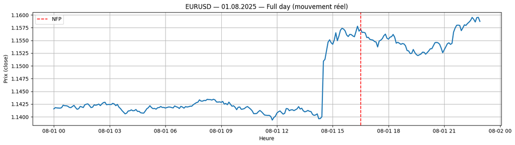

```python
plt.figure(figsize=(14,4))
plt.plot(pd.to_datetime(prices_0801["ts_utc"]), prices_0801["close"], lw=2)
plt.axvline(pd.Timestamp("2025-08-01 14:30:00"), color="red", linestyle="--", label="NFP")
plt.title("EURUSD — 01.08.2025 — Full day (mouvement réel)")
plt.xlabel("Heure")
plt.ylabel("Prix (close)")
plt.legend()
plt.grid(True)
plt.tight_layout()
plt.show()
```

👉 **Ici :**

- Single wave évidente
- Aucune ambiguïté
- Le moteur n'a pas le droit de se tromper ici

## 🧱 CELLULE 10 — Répéter pour 11.09.2025

```python
events_0911 = load_events("2025-09-11")
cons_0911 = load_consensus("2025-09-11")

merged_0911 = merge_events_and_consensus(events_0911, cons_0911)
merged_0911["surprise"] = merged_0911["actual"] - merged_0911["estimate"]

merged_0911[[
    "event_title", "actual", "estimate", "surprise"
]].sort_values("surprise", ascending=False)
```

|  | event_title | actual | estimate | surprise |
| --- | --- | --- | --- | --- |
| 33 | CPI | 323.980 | 323.89 | 0.09 |
| 0 | RICS House Price Balance | -19.000 | NaN | NaN |
| 1 | BSI Large Manufacturing QoQ | 3.800 | NaN | NaN |
| 2 | Stock Investment by Foreigners | 108.600 | NaN | NaN |
| 3 | PPI MoM | -0.200 | NaN | NaN |
| 4 | PPI YoY | 2.700 | NaN | NaN |
| 5 | Stock Investment by Foreigners | 108.600 | NaN | NaN |
| 6 | BSI Large Manufacturing QoQ | 3.800 | NaN | NaN |
| 7 | Foreign Bond Investment | 245.100 | NaN | NaN |
| 8 | PPI MoM | -0.200 | NaN | NaN |
| 9 | PPI YoY | 2.700 | NaN | NaN |
| 10 | Stock Investment by Foreigners | 108.600 | NaN | NaN |
| 11 | BSI Large Manufacturing QoQ | 3.800 | NaN | NaN |
| 12 | Foreign Bond Investment | 245.100 | NaN | NaN |
| 13 | PPI MoM | -0.200 | NaN | NaN |
| 14 | PPI YoY | 2.700 | NaN | NaN |
| 15 | Stock Investment by Foreigners | 108.600 | NaN | NaN |
| 16 | BSI Large Manufacturing QoQ | 3.800 | NaN | NaN |
| 17 | Foreign Bond Investment | 245.100 | NaN | NaN |
| 18 | PPI MoM | -0.200 | NaN | NaN |
| 19 | PPI YoY | 2.700 | NaN | NaN |
| 20 | Foreign Bond Investment | 245.100 | NaN | NaN |
| 21 | Industrial Production MoM | -1.200 | NaN | NaN |
| 22 | Industrial Production YoY | -2.700 | NaN | NaN |
| 23 | Industrial Production YoY | -2.700 | NaN | NaN |
| 24 | Industrial Production MoM | -1.200 | NaN | NaN |
| 25 | Continuing Jobless Claims | 1939.000 | NaN | NaN |
| 26 | Core Inflation Rate MoM | 0.300 | NaN | NaN |
| 27 | Core Inflation Rate YoY | 3.100 | NaN | NaN |
| 28 | CPI s.a | 323.364 | NaN | NaN |
| 29 | Inflation Rate YoY | 2.900 | NaN | NaN |
| 30 | Initial Jobless Claims | 263.000 | NaN | NaN |
| 31 | Jobless Claims 4-week Average | 240.500 | NaN | NaN |
| 32 | Inflation Rate MoM | 0.400 | NaN | NaN |
| 34 | Current Account | 14.800 | NaN | NaN |
| 35 | Balance of Trade | 13.170 | NaN | NaN |

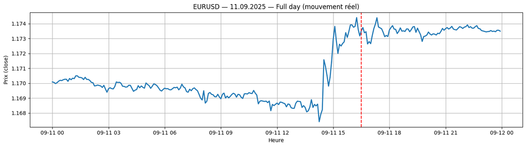

```python
prices_0911 = load_prices_full_day("2025-09-11")

plt.figure(figsize=(14,4))
plt.plot(pd.to_datetime(prices_0911["ts_utc"]), prices_0911["close"], lw=2)
plt.axvline(pd.Timestamp("2025-09-11 14:30:00"), color="red", linestyle="--")
plt.title("EURUSD — 11.09.2025 — Full day (mouvement réel)")
plt.xlabel("Heure")
plt.ylabel("Prix (close)")
plt.grid(True)
plt.tight_layout()
plt.show()
```